# Chapter 3:Exploratory Data Analysis

## Load DM/Dollar exchange rate

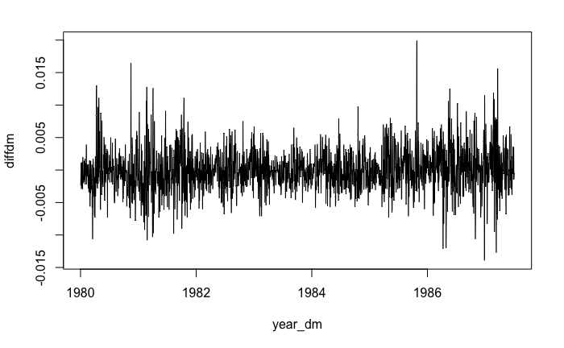

```r
data(Garch, package = "Ecdat")
dm = Garch$dm
diffdm = diff(dm)
n = length(diffdm)
year_dm = 1980 + (1:n)*(1987.5 - 1980)/n
plot(year_dm, diffdm, type="l")
```

## European Stock Indices

```r
data(EuStockMarkets)
mode(EuStockMarkets)
```

```
[1] "numeric"
```

```r
class(EuStockMarkets)
```

```
[1] "mts"    "ts"     "matrix"
```

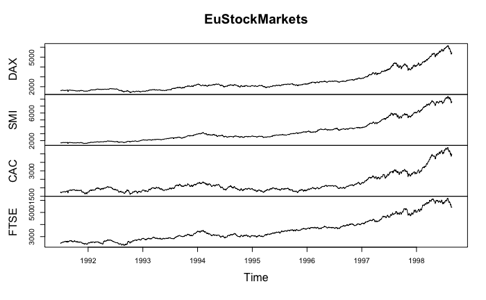

```r
plot(EuStockMarkets)
```

## Log return European Stock Indice

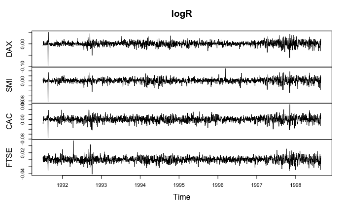

```r
logR = diff(log(EuStockMarkets))
plot(logR)
```

## In other way to plot this data like data frame:

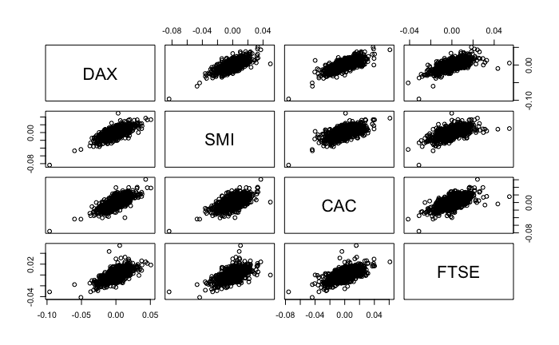

```r
plot(as.data.frame(logR))
```

## Normal plot and test each for normality using the Shapiro-Wilk test

```
    Shapiro-Wilk normality test

data:  logR[, i]
W = 0.95384, p-value < 2.2e-16


    Shapiro-Wilk normality test

data:  logR[, i]
W = 0.95537, p-value < 2.2e-16


    Shapiro-Wilk normality test

data:  logR[, i]
W = 0.98203, p-value = 1.574e-14


    Shapiro-Wilk normality test

data:  logR[, i]
W = 0.97994, p-value = 1.754e-15
```

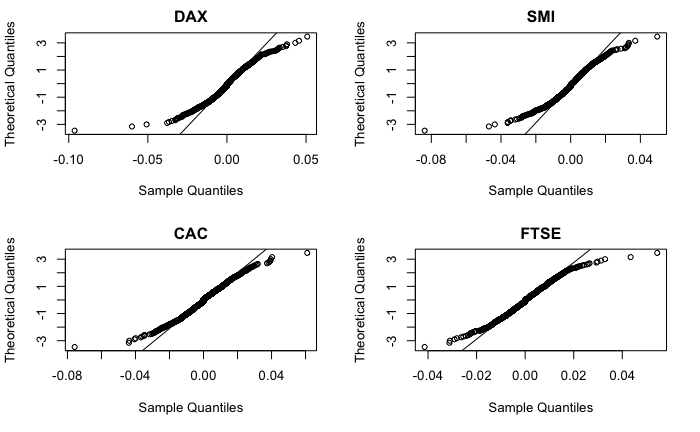

```r
par(mfrow=c(2,2))
for (i in colnames(logR))
{
  qqnorm(logR[,i], datax = T, main=i)
  qqline(logR[,i], datax = T)
  print(shapiro.test(logR[,i]))
}
```

```r
n = dim(logR)[1]
q_grid = (1:n)/(n+1)
df_grid = c(1,4,6,10,20,30)
index.names = dimnames(logR)[[2]]
cat(index.names)
```

```
DAX SMI CAC FTSE
```

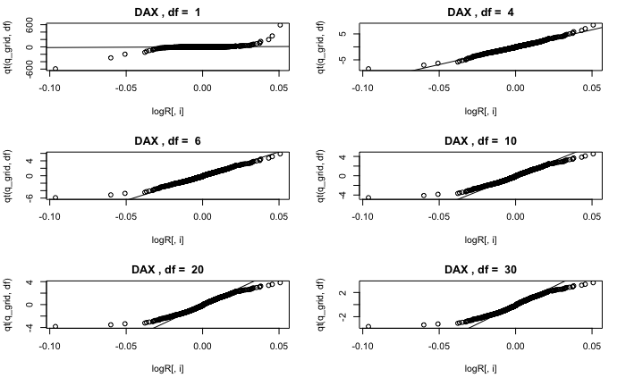

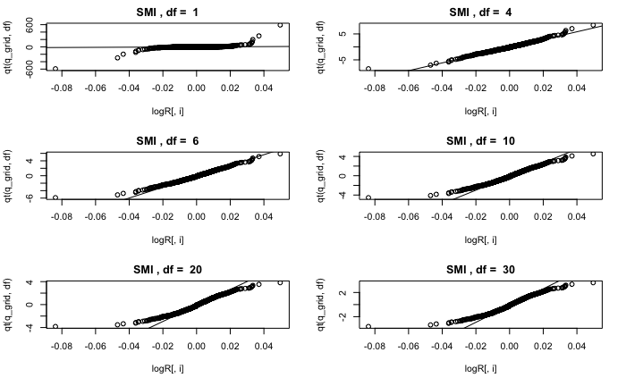

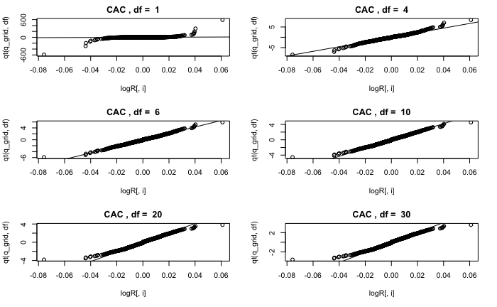

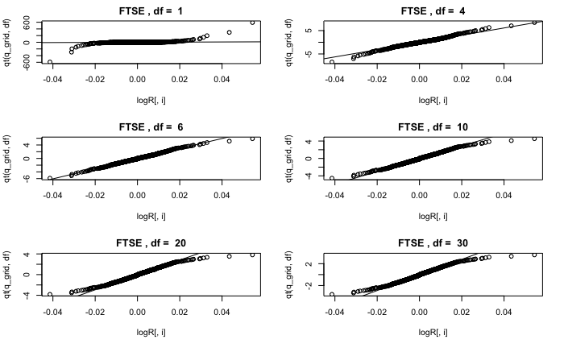

```r
for (i in 1:4)
{
  par(mfrow=c(3,2))
  for (df in df_grid)
  {
    qqplot(logR[,i], qt(q_grid, df), main=paste(index.names[i], ", df = ", df))
    abline(lm(qt(c(0.25,0.75), df=df)~quantile(logR[,i], c(0.25,0.75))))
  }
}
```

## Campare plot of kde, t-distribution and normal distribution of DAX indice

```r
library(fGarch)
x = seq(-0.1,0.1,0.001)
par(mfrow=c(1,1))
df = 4
adjust = 1.4
cat(sqrt(df/(df-2))/qt(0.75, df))
```

```
1.909301
```

```r
mad_t = mad(logR[,"DAX"], constant = sqrt(df/(df-2))/qt(0.75, df))
# density plot
plot(density(logR[,1], adjust = adjust), lwd=2, ylim=c(0,60), main = "DAX indices")
# t-plot
lines(x, dstd(x, mean=median(logR[,1]), sd=mad_t, nu=df), lty=5, lwd=2, col="red")
```

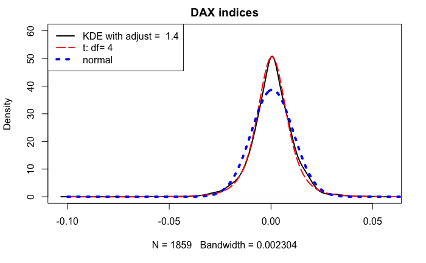

```r
# normal plot
lines(x, dnorm(x, mean=mean(logR[,1]), sd=sd(logR[,1])), lty=3, lwd=4, col="blue")
legend("topleft", c(paste("KDE with adjust = ", adjust), paste("t: df=", df), "normal"), lwd=c(2,2,4), lty=c(1,5,3), col=c("black", "red", "blue"))
```

```r
# the bandwidth used par defaut
bw_defaut = bw.nrd0(logR[,1])
cat("bw default: ",bw_defaut)
```

```
bw default:  0.001645421
```

```r
# kernel used by defaut is gaussian
# bandwidth modify by adjust
adj = 3/2
new_bw = bw_defaut*adj
cat("\nnew bandwidth: ",new_bw)
```

```
new bandwidth:  0.002468131
```

## Campare plot of kde, t-distribution and normal distribution of CAC indice:

```r
library(fGarch)
x = seq(-0.1,0.1,0.001)
par(mfrow=c(1,1))
df = 6
adjust = 1.6
cat(sqrt(df/(df-2))/qt(0.75, df))
```

```
1.706823
```

```r
mad_t = mad(logR[,3], constant = sqrt(df/(df-2))/qt(0.75, df))
# density plot
plot(density(logR[,3], adjust = adjust), lwd=2, ylim=c(0,60), main = paste("CAC indice"))
# t-plot
lines(x, dstd(x, mean=median(logR[,3]), sd=mad_t, nu=df), lty=5, lwd=2, col="red")
```

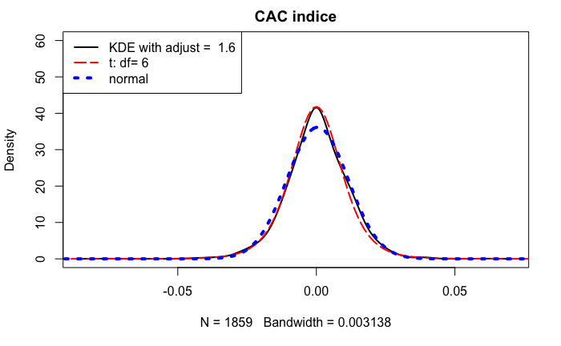

```r
# normal plot
lines(x, dnorm(x, mean=mean(logR[,3]), sd=sd(logR[,3])), lty=3, lwd=4, col="blue")
legend("topleft", c(paste("KDE with adjust = ", adjust), paste("t: df=", df), "normal"), lwd=c(2,2,4), lty=c(1,5,3), col=c("black", "red", "blue"))
```

# McDonald’s Price and Return:

Daily stock prices and returns of McDonald’s Corporation (MCD) over period Jan-4-10 to Sep-5-14

```r
setwd("~/dev/DataFinancialAnalyst")
MC_data = read.csv("datasets/MCD_PriceDaily.csv", header = TRUE)
head(MC_data)
```

|  | Date | Open | High | Low | Close | Volume | Adj.Close |
| --- | --- | --- | --- | --- | --- | --- | --- |
| 1 | 1/4/2010 | 62.63 | 63.07 | 62.31 | 62.78 | 5839300 | 53.99 |
| 2 | 1/5/2010 | 62.66 | 62.75 | 62.19 | 62.30 | 7099000 | 53.58 |
| 3 | 1/6/2010 | 62.20 | 62.41 | 61.06 | 61.45 | 10551300 | 52.85 |
| 4 | 1/7/2010 | 61.25 | 62.34 | 61.11 | 61.90 | 7517700 | 53.24 |
| 5 | 1/8/2010 | 62.27 | 62.41 | 61.60 | 61.84 | 6107300 | 53.19 |
| 6 | 1/11/2010 | 62.02 | 62.43 | 61.85 | 62.32 | 6081300 | 53.60 |

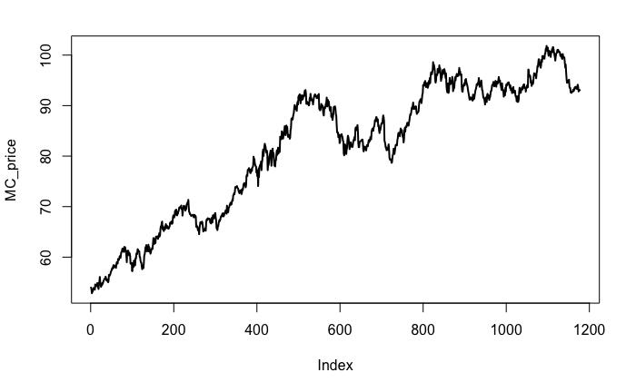

```r
MC_price = MC_data[,7]
plot(MC_price, type="l", lwd=2)
```

- This price series is not stationary because we can see that line go up over time and it have incease tendance, maybe it have a cycle saisonary but it is not stationary.
- Transform the prices into log returns call LogRet, plot it and reponse question precedent

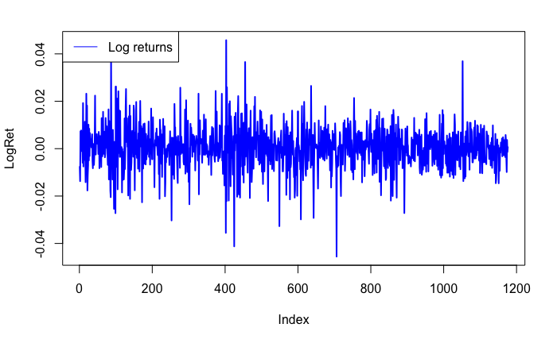

```r
LogRet = diff(log(MC_price))
plot(LogRet, type="l", lwd=2, col="blue")
legend("topleft", "Log returns", lty = 1, col="blue")
```

## Histogram with 80 bins

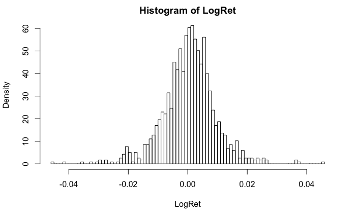

```r
hist(LogRet, breaks=80, freq = F)
```

## Normal plot of LogRet

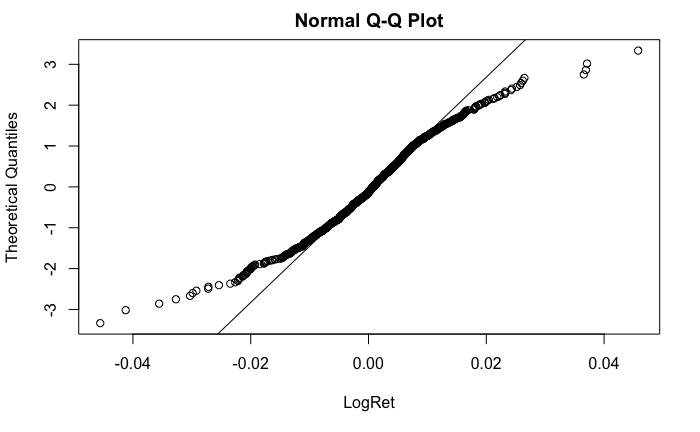

```r
qqnorm(LogRet, datax=T, main="Normal Q-Q Plot", ylab = "LogRet")
qqline(LogRet, datax=T)
```

- `LogRet` have Normal QQ Plot from convex to concave, that is mean this series got heavier-tailed distribution
- After saw Histograme plot and Normal QQ plot, we can say that althought Log return of daily prices McDonal have sysmetric distribution but it have heavier-tailed distribution and it have not straight line in QQ plot. So, we may conclude that this series is not normal distribution

## Shapiro - Wilk test normal distribution

```r
shapiro.test(LogRet)
```

```
    Shapiro-Wilk normality test

data:  LogRet
W = 0.96956, p-value = 5.226e-15
```

- Also that the Shapiro - Wilk test have P-value = 0 to reject null hypothese. So this test comfirm that LogRet is not normality

# Exercises:

## 1:

```r
setwd("~/dev/DataFinancialAnalyst")
ford = read.csv("datasets/ford.csv", header = T)
head(ford)
```

|  | X | X.m..d..y | FORD |
| --- | --- | --- | --- |
| 1 | 1 | 2/2/1984 | 0.025236590 |
| 2 | 2 | 2/3/1984 | -0.036923080 |
| 3 | 3 | 2/6/1984 | -0.015974440 |
| 4 | 4 | 2/7/1984 | -0.006493506 |
| 5 | 5 | 2/8/1984 | -0.013071900 |
| 6 | 6 | 2/9/1984 | -0.016556290 |

```r
ford_R = ford[,3]
```

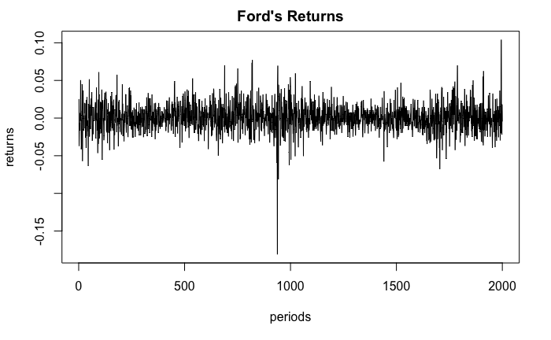

```r
plot(ford_R, main="Ford's Returns", xlab="periods", ylab="returns", type="l")
```

```r
ind = which(ford_R == ford_R[ford_R < -0.15])
#cat("date have anormaly data: ", ford[ind,])
ford[ind,]
```

|  | X | X.m..d..y | FORD |
| --- | --- | --- | --- |
| 938 | 938 | 10/19/1987 | -0.1810089 |

- find the sample mean, median, standard deviation of Ford returns

```r
mean_r = mean(ford_R)
median_r = median(ford_R)
sd_r = sd(ford_R)
cat("sample mean: ", mean_r)
```

```
sample mean:  0.0007600789
```

```r
cat("\nsample median: ", median_r)
```

```
sample median:  0
```

```r
cat("\nsample standard deviation: ", sd_r)
```

```
sample standard deviation:  0.01831557
```

- Do the normal QQ plot of Ford return

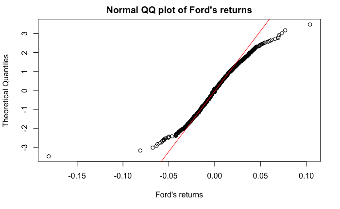

```r
qqnorm(ford_R, datax=T, main="Normal QQ plot of Ford's returns", ylab="Ford's returns")
qqline(ford_R, datax=T, col="red")
```

- Figure above show us that Ford’s returns distribution have heavy tail distribution as we saw on the top and bottom of scatter plot, this distribution have one left heavier tail than other right. It means Ford’s return is not normality.
- Shapiro - Wilk test normality

```r
result = shapiro.test(ford_R)
cat("P-value: ",result$p.value)
```

```
P-value:  5.989572e-22
```

- with this P value we can reject null hypothese with 95% confidential

## t-plot of Ford’s Returns

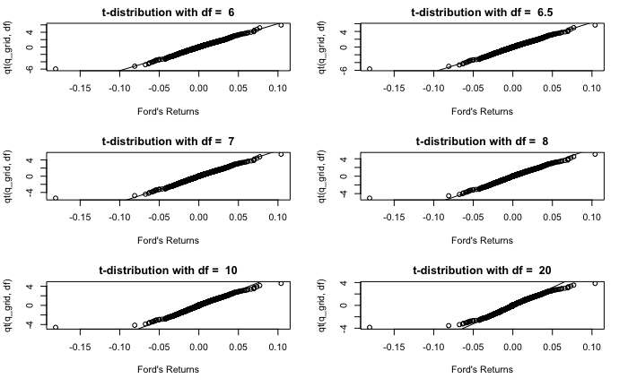

```r
grid_df = c(6,6.5,7,8,10,20)
n = length(ford_R)
q_grid = (1:n)/(n+1)
par(mfrow=c(3,2))
for (df in grid_df)
{
  qqplot(ford_R, qt(q_grid, df), main = paste("t-distribution with df = ", df), xlab="Ford's Returns")
  qqline(ford_R, datax = T)
}
```

- After modify grid of degree of freedom, i found df = 6.5 of t-distribution best fitting Ford’s Returns
- In all of case, any of value df, we saw that data point of Black Friday 19 Oct 1987 was ignored, so i think that this data point maybe ignore out of data when looking best choices of df